# Topologia

CORE Lab

## Introducion

¿Que es la topologia?

- Un enfoque en la estructura de la red

¿Por que utilizamos esta familia de medidas?

- Indica compensaciones (resiliencia vs. efectividad)
- Importante para ejecutar antes de la centralidad

## Ejemplo #1

[interactive chart not shown]

## Ejemplo #2

[interactive chart not shown]

## Ejemplo #3

[interactive chart not shown]

## ¿Que medidas existen?

- Tamaño de una Red
- Densidad de una Red
- Grado Medio
- Promedio de la Distancia de un Camino
- Reciprocidad (Datos Dirigido)
- Coeficiente de Agrupación en Clústeres
- Índice “E-I”
- Jerarquía (Datos Dirigido)
- Centralización
- Diametro

## Sumario

Topología de Redes: Dimensión Provincial-Cosmopolita

1. Suicidio
2. La Industria del Vestido
3. Eficacia de Redes
4. Medidas: Densidad, Grado medio, y Coeficiente de agrupación

Topología de Redes: Dimensión Jerárquica de Heterarquía

1. Centralización
2. Medidas Alternativas

Resumen: Eficacia de la Red

Topología de Redes  
**Dimensión Provincial-Cosmopolita**

## Obteniendo un Trabajo

Contactos Personales (lazos) y obteniendo un trabajo

- 19% utilizaron medios formales
- 19% aplicaron directamente por el trabajo
- 56% utilizaron contactos personales

Débil vs. Fuerte (lazos personales)

- 17% cuentan que veían sus contactos con regularidad (lazo fuerte)
- 56% cuentan que veían sus contactos de vez en cuando (lazo débil)
- 28% cuentan que rara vez veían sus contactos (lazo débil)

Lazos Personales y Satisfacción Laboral

- Medios Formales – 76% tasa de satisfacción
- Aplicación Directa – 85% tasa de satisfacción
- Lazos Personales – 91% tasa de satisfacción

## Círculos Sociales y Lazos Débiles

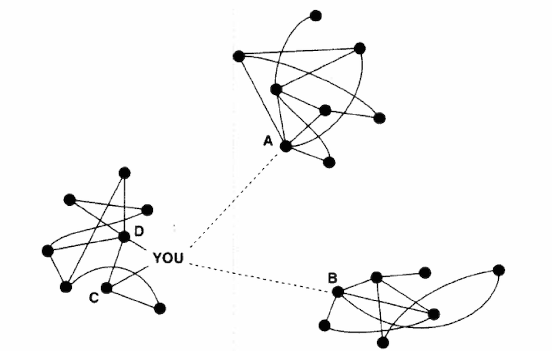

## Lazos Débiles y Fuertes

- Actores con muchos lazos débiles generalmente encuentran más facilidad para acceder a información (u otros tipos de recursos) de distintas partes de la estructura social.
- Actores que tienen pocos lazos débiles son más propensas a “limitarse a las noticias provinciales y las opiniones de sus amigos más cercanos” (Granovetter 1983)

## Pescosolido y Georgianna: Densidad y Suicidio

- Las personas inmersas en redes dispersas a menudo carecen de lazos sociales que proporcionan el apoyo necesario en tiempos de crisis.
- Las personas inmersas en redes densas son a menudo desconectados de personas fuera de su grupo social inmediato, y por lo tanto carecen de lazos con personas (por ejemplo, amigos y familia) que pueden evitar que lleguen a tomar un paso final o fatal.

## Pescosolido y Georgianna: Densidad y Suicidio - Densidad de la Red

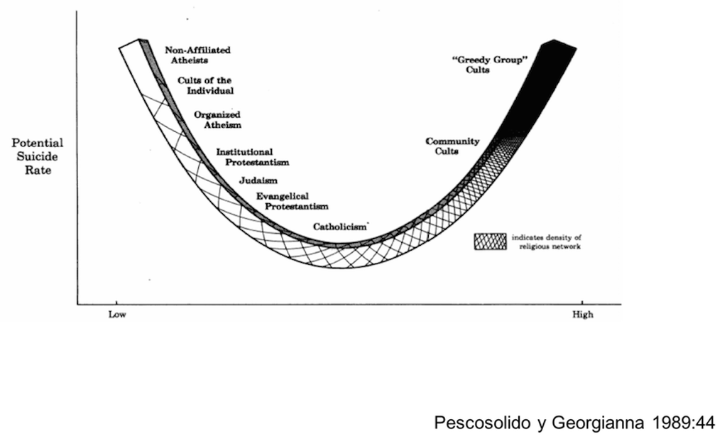

## Uzzi:La Industria del Vestido

- Las empresas examinados por Uzzi tenían la tendencia de dividir sus interacciones en el mercado en dos tipos: relaciones del “mercado” o “condiciones de plena competencia” (es decir, vínculos débiles) y “especiales” o relaciones “cerradas” (es decir, lazos fuerte), lo que se refiere a lazos “integrado”
- Vínculos incrustado fueron especialmente importantes en situaciones donde la confianza era importante, donde información detallada tuvo que ser pasado a otro grupo, y cuando ciertos formas para solucionar problemas estaban en la agenda (Uzzi 1996:677)
- Por su parte, Uzzi también descubrió que las empresas que están muy integrados sufren porque dejan de tener acceso a información de partes distantes del red que los hace vulnerables a situaciones que evolucionan rápidamente

## Uzzi:La Industria del Vestido - Densidad de la Red

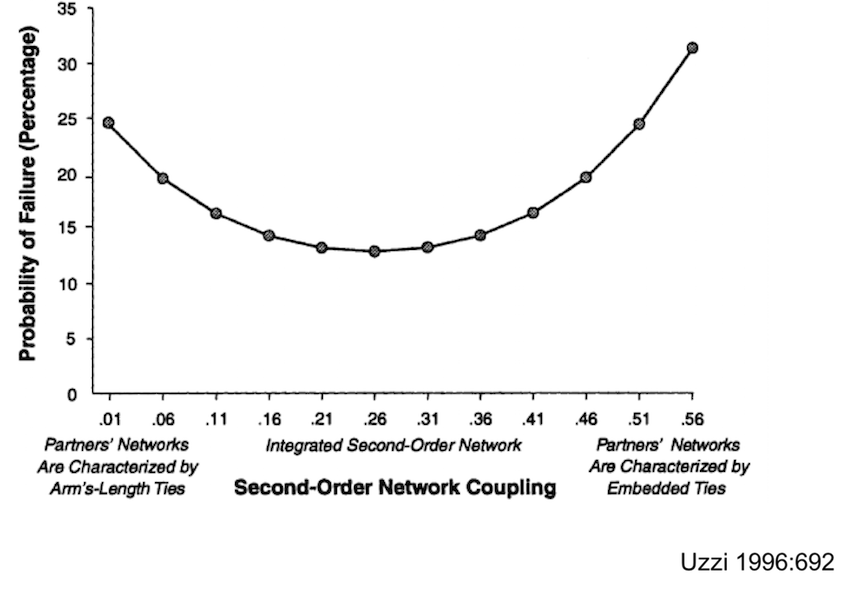

## Topología de Redes: Dimensión Provincial-Cosmopolita

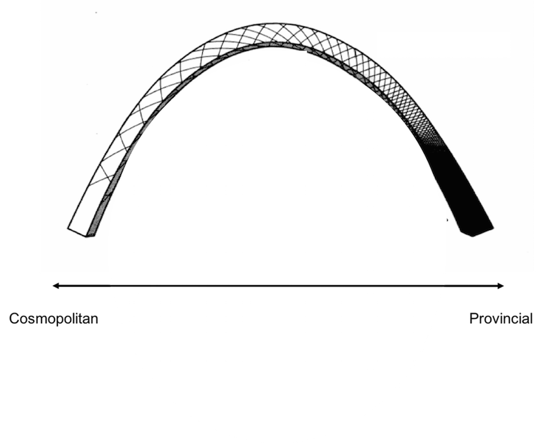

## Topología de Redes: Dimensión Provincial-Cosmopolita

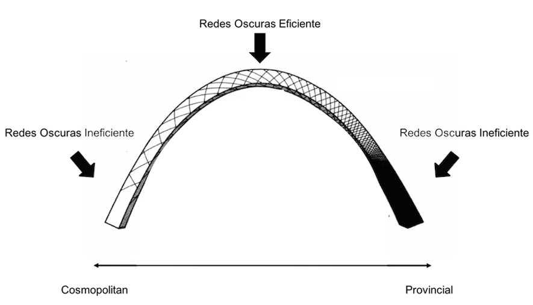

## Densidad, Grado y Agrupación

- Densidad de Red = Proporción de Lazos Actuales vs Lazos Posibles
- Densidad tiende a reducir cuando el tamaño de la red aumenta (es decir, el numero de nodos)
- Esto hace que sea difícil para nosotros usar la densidad para comparar las redes de diferentes tamaños
- Grado medio es una medida alternativa - la suma de las puntuaciones individuales de grado dividido por el número total de actores en la red
- Coeficiente de Agrupación: Densidad de una red alterada

## Densisdad, Grado y Agrupación

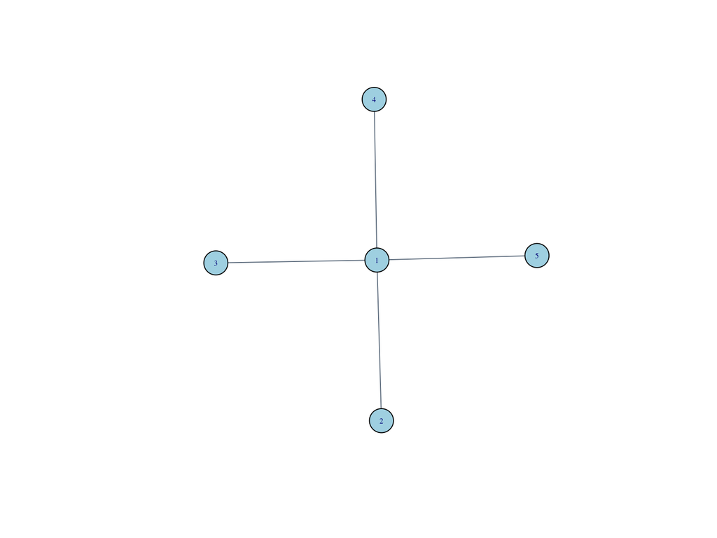

La densidad es 0.4 y el grado medio es 1.6.

## Densisdad, Grado y Agrupación

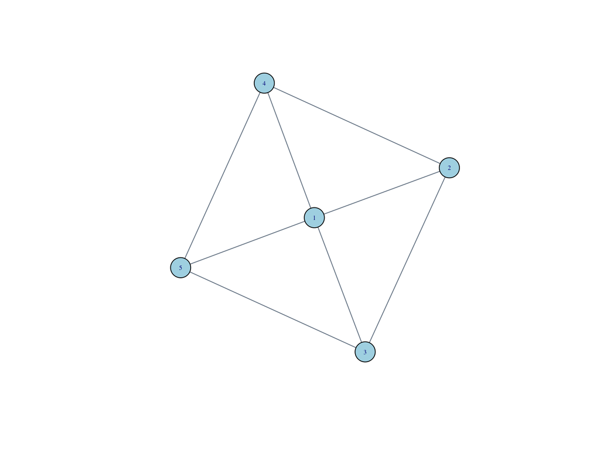

La densidad es 0.8 y el grado medio es 3.2.

## Densisdad, Grado y Agrupación

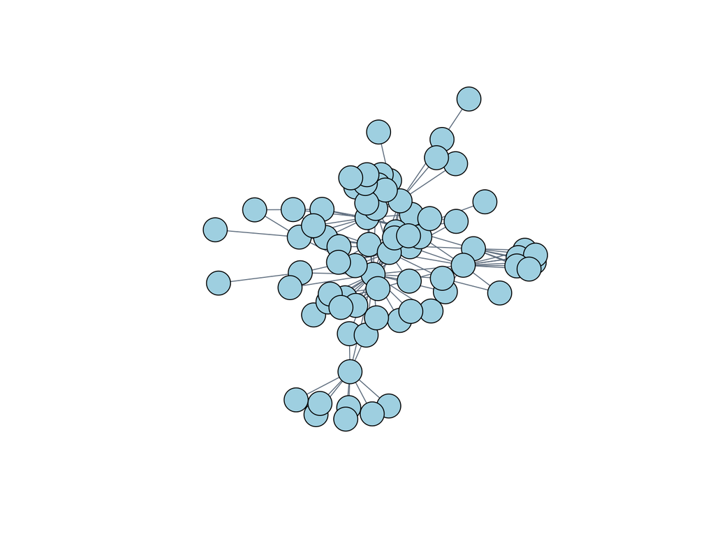

La densidad es 0.0868079 y el grado medio es 6.5974026.

Topología de Redes  
**Dimensión Jerárquica y Heterarquía**

## Redes: Jerárquia y Heterarquía

- Los primeros son vistos como descentralizado, informal y/u orgánicos de las organizaciones, mientras que segundos son vistos como tipos centralizado, formal y/o burocrática (Burns y Stalker, 1961; Powell 1990; Ronfeldt y Arquilla 2001)
- Esta distinción es útil (y apropiado) en algunos contextos (véase, por ejemplo, Arquilla y Ronfeldt 2001; Castells 1996; Podolny y Página 1998; Powell y Smith-Doerr, 1994; Ronfeldt y Arquilla 2001), pero dentro de SNA, todo es una red, algunos de cuales son altamente centralizado y algunos de cuales no son
- (Para nuestros propósitos) es probable que sea mejor considerar estos dos tipos ideales como postes a cada extremo de un continuo que va desde formas muy descentralizada, a otros extremos que son altamente centralizado

## Redes: Jerárquia y Heterarquía

- Stark (La Iglesia Mormona) – la centralización es buena pero…
  - “Sería un error destacar sólo la naturaleza jerárquica de la autoridad mormona y sus aspectos autoritarios, porque los Santos de los Últimos Días muestran un sorprendente grado de participación de aficionados en todos los niveles de su estructura formal. Por otra parte, este cuerpo muy autoritario también muestra niveles extraordinarios de democracia participativa y en gran medida los miembros son la iglesia. Un aspecto central de esto es que entre los Santos de los Últimos Días, ser un sacerdote es una posición no remunerado que todos los hombres comprometidos se espera que cumplan”(Stark 2005:125)
- David Tucker (Redes Terroristas)

## Redes: Jerárquia y Heterarquía

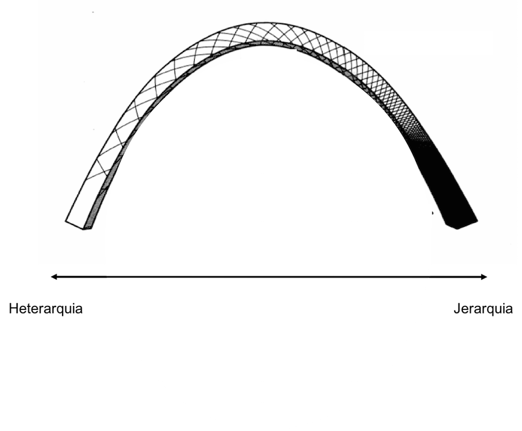

## Redes: Jerárquia y Heterarquía

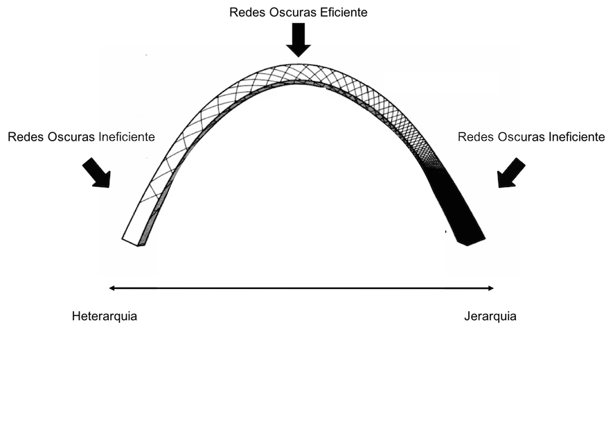

Topología de Redes  
**Dimensión Jerárquica y Heterarquía: Centralizacion**

## Centralizacion

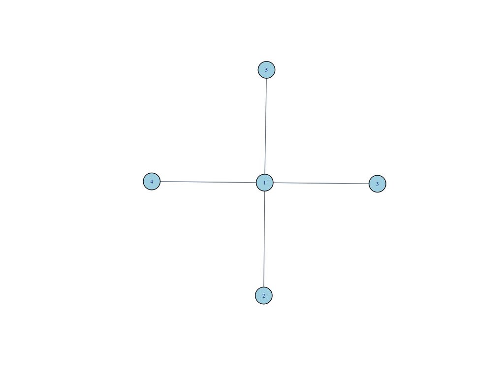

La centralizacion de grado es 0.6.

## Centralizacion

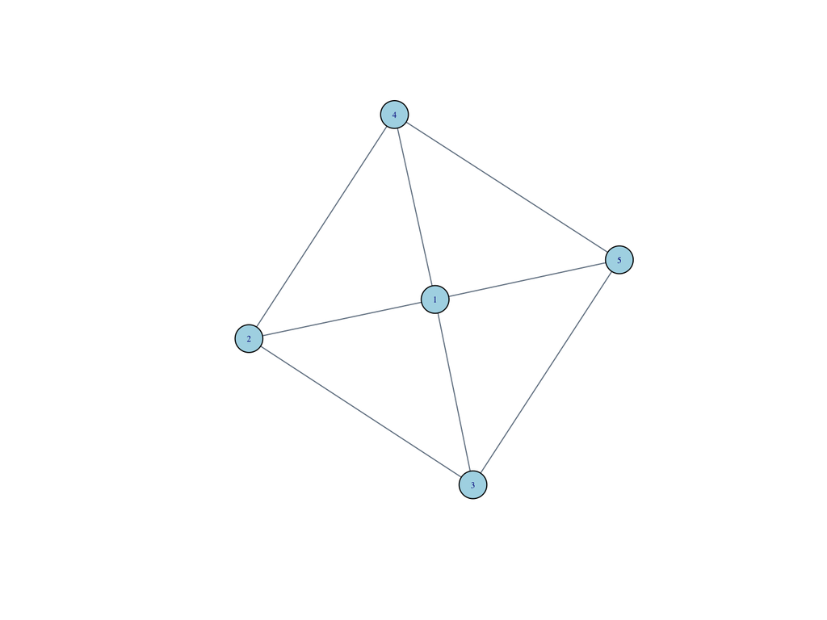

La centralizacion de grado es 0.2.

## Centralizacion

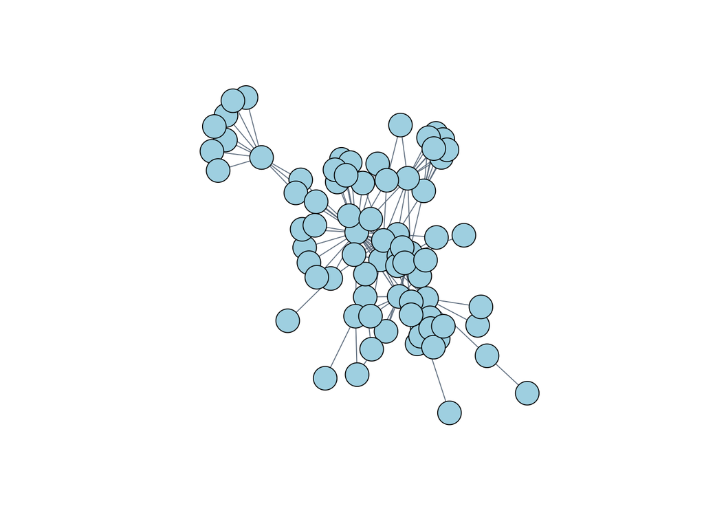

La centralizacion de grado es 0.3868763.

Topología de Redes  
**Resumen:Eficacia de la Red**

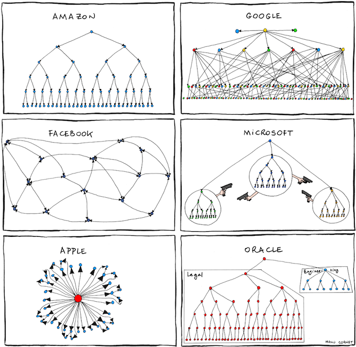

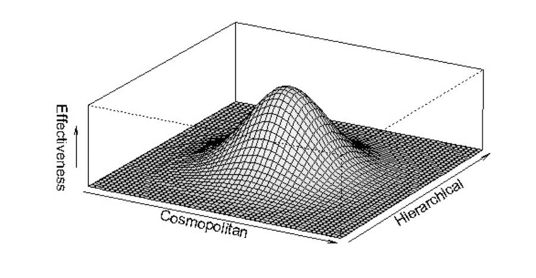